# DEDS_Portfolio_Week-10

Van Pjotr en Sennen

De opdracht van deze week is:

## Opdracht:

Bouw een neuraal netwerk met generatieve AI

## Doel:

Het doel van deze opdracht is om een basisbegrip van neurale netwerken te ontwikkelen door een eenvoudig neuraal netwerk te implementeren, zonder gebruik te maken van backpropagation en gradient descent. Er dient voor het trainen van het model een simpel algoritme gebruikt te worden. Je moet de code zelf goed kan uitleggen.

### Requirements:

1. NN heeft 4 input nodes, 1 hidden layer met een door de student gekozen aantal nodes en 1 output node.
2. Gebruik 1 tot 5 input datapunten met bijbehorende output (antwoorden)
3. Maak gebruik van arrays
4. Het mag geen backpropagation gebruiken en ook niet Gradient Descent algoritme.

### Stappen:

De volgende algemene stappen zou je terug moeten kunnen vinden of herkennen in de gegenereerde code van je NN. Dit is een hulpmiddel voor je om de code te begrijpen. Het is niet erg als jou gegenereerde code hier iets van afwijkt.

1. Definieer de structuur van het neurale netwerk, inclusief het aantal input nodes, het aantal nodes in de hidden layer en het aantal output nodes.
2. Initialiseer de gewichten van het netwerk willekeurig.
3. Implementeer de feedforward-methode om de input door het netwerk te sturen en de output te berekenen.
4. Bereken de error of fout tussen de voorspelde output en de werkelijke output.
5. Pas de gewichten niet aan met behulp van backpropagation en gradient descent. In plaats daarvan kunnen de studenten ervoor kiezen om de gewichten met een eenvoudige regel aan te passen.
6. Train het netwerk met behulp van de gegeven training samples en evalueer de prestaties ervan.

### Training:

Het kan zijn dat de LLM alsnog, direct of indirect, de backpropagation en gradient descent trainingsalgoritme gebruikt. Andere termen die hier direct te maken mee hebben zijn de ‘afgeleide’ (in het engels de derivative). Dat zie je als je bijvoorbeeld het volgende ziet in de code die de LLM genereerd:

- inputToHiddenWeights[i, j] += error * input[i] * hiddenOutput[j] * (1 - hiddenOutput[j]); Metname als het “… (1 - …)” gedeelte. Je wil het liefst code zien dat er als volgt uit ziet:
- inputToHiddenWeights[i, j] += error * input[i] * hiddenOutput[j];

## Maak het model from scratch:

```
Epoch 1, Average Error: 0.5105571902842014
Epoch 2, Average Error: 0.5041654016133469
Epoch 3, Average Error: 0.502018387057321
Epoch 4, Average Error: 0.5038056409321545
Epoch 5, Average Error: 0.5032324541562966
Epoch 6, Average Error: 0.5000931161826749
Epoch 7, Average Error: 0.49606796091092453
Epoch 8, Average Error: 0.4919766465647807
Epoch 9, Average Error: 0.48808307227265035
Epoch 10, Average Error: 0.484461383443363
Epoch 11, Average Error: 0.481091783248895
Epoch 12, Average Error: 0.47787336850110873
Epoch 13, Average Error: 0.47465423819328834
Epoch 14, Average Error: 0.47129311236241955
Epoch 15, Average Error: 0.4677138223822269
Epoch 16, Average Error: 0.4639169444833012
Epoch 17, Average Error: 0.4599530702797703
Epoch 18, Average Error: 0.45588753925491016
Epoch 19, Average Error: 0.451776989683938
Epoch 20, Average Error: 0.44766029026146303
Epoch 21, Average Error: 0.4435584054172921
Epoch 22, Average Error: 0.4394776288194856
Epoch 23, Average Error: 0.4354131315191134
Epoch 24, Average Error: 0.4313521671717597
Epoch 25, Average Error: 0.4272776939523346
Epoch 26, Average Error: 0.4231734872507178
Epoch 27, Average Error: 0.4190310616140589
Epoch 28, Average Error: 0.4148571185093611
Epoch 29, Average Error: 0.4106786016840833
Epoch 30, Average Error: 0.4065422004081922
Epoch 31, Average Error: 0.40250724430214085
Epoch 32, Average Error: 0.3986343814429553
Epoch 33, Average Error: 0.39497461295783964
Epoch 34, Average Error: 0.3915625086017043
Epoch 35, Average Error: 0.3884147160293335
Epoch 36, Average Error: 0.3855324548609125
Epoch 37, Average Error: 0.3829058174247415
Epoch 38, Average Error: 0.3805181154686392
Epoch 39, Average Error: 0.37834936286941856
Epoch 40, Average Error: 0.3763786750511824
```

[output cut: 45 more lines]

```
Epoch 86, Average Error: 0.3549687256907313
Epoch 87, Average Error: 0.35537031119636686
Epoch 88, Average Error: 0.35584731547102855
Epoch 89, Average Error: 0.35640768865957373
Epoch 90, Average Error: 0.3570599874726786
Epoch 91, Average Error: 0.3578132736703042
Epoch 92, Average Error: 0.35867695494945206
Epoch 93, Average Error: 0.35966055963116633
Epoch 94, Average Error: 0.36077344064603073
Epoch 95, Average Error: 0.36202441097563554
Epoch 96, Average Error: 0.36342132179386116
Epoch 97, Average Error: 0.36497060525567543
Epoch 98, Average Error: 0.3666768146024494
Epoch 99, Average Error: 0.36854220273635896
Epoch 100, Average Error: 0.37056638419234983
```

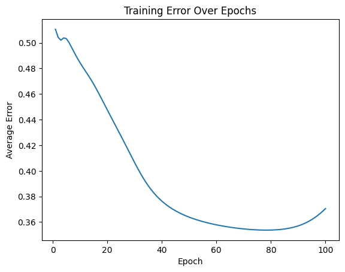

```
array([0.27233558])
```

```python
import numpy as np
import matplotlib.pyplot as plt

class NeuralNetwork:
    def __init__(self, input_size, hidden_size, output_size):
        self.input_size = input_size
        self.hidden_size = hidden_size
        self.output_size = output_size

        # Initialize weights randomly
        self.input_to_hidden_weights = np.random.randn(input_size, hidden_size)
        self.hidden_to_output_weights = np.random.randn(hidden_size, output_size)

    def sigmoid(self, x):
        return 1 / (1 + np.exp(-x))

    def feedforward(self, inputs):
        # Input to hidden layer
        hidden_sum = np.dot(inputs, self.input_to_hidden_weights)
        hidden_output = self.sigmoid(hidden_sum)

        # Hidden to output layer
        output_sum = np.dot(hidden_output, self.hidden_to_output_weights)
        output = self.sigmoid(output_sum)

        return output

    def train(self, inputs, targets, epochs):
        errors = []
        for epoch in range(epochs):
            epoch_error = 0
            for i in range(len(inputs)):
                # Feedforward
                input_data = inputs[i]
                target = targets[i]

                hidden_sum = np.dot(input_data, self.input_to_hidden_weights)
                hidden_output = self.sigmoid(hidden_sum)

                output_sum = np.dot(hidden_output, self.hidden_to_output_weights)
                output = self.sigmoid(output_sum)

                # Calculate error
                error = target - output
                epoch_error += np.mean(np.abs(error))

                # Update weights (no backpropagation)
                self.input_to_hidden_weights += np.outer(input_data, hidden_output) * error
                self.hidden_to_output_weights += np.outer(hidden_output, output) * error

            # Append average error for this epoch
            errors.append(epoch_error / len(inputs))

            # Print average error for this epoch
            print(f'Epoch {epoch + 1}, Average Error: {errors[-1]}')

        # Plot the training error over epochs
        plt.plot(range(1, epochs + 1), errors)
        plt.xlabel('Epoch')
        plt.ylabel('Average Error')
        plt.title('Training Error Over Epochs')
        plt.show()

# Example usage
inputs = np.array([[0, 0, 1, 1],
                   [0, 1, 1, 0],
                   [1, 0, 1, 1],
                   [1, 1, 1, 0]])
targets = np.array([[0], [1], [1], [0]])

nn = NeuralNetwork(input_size=4, hidden_size=3, output_size=1)
nn.train(inputs, targets, epochs=100)
nn.feedforward([0, 0, 1, 1])
```

## Gebaseerd op het C# Script:

In het begin van deze opdracht moesten we ook een c# script maken. Waar we ook ons eigen neural network moesten bouwen. Hieronder is een python script gebasseerd op het c# script.

Hier voegen we ook backpropagation toe. Dat zorgt ervoor dat het model beter kan leren, door fouten te corrigeren en veranderingen te maken in de gewichten van het model.

```
Epoch 1, Average Error: 0.020241418340183115
Epoch 2, Average Error: 0.01974383285036374
Epoch 3, Average Error: 0.019258445687551418
Epoch 4, Average Error: 0.018784960203589662
Epoch 5, Average Error: 0.018323086793048504
Epoch 6, Average Error: 0.017872542738384123
Epoch 7, Average Error: 0.017433052057591825
Epoch 8, Average Error: 0.01700434535438522
Epoch 9, Average Error: 0.016586159670923695
Epoch 10, Average Error: 0.016178238343110718
Epoch 11, Average Error: 0.01578033085846886
Epoch 12, Average Error: 0.01539219271660297
Epoch 13, Average Error: 0.015013585292249276
Epoch 14, Average Error: 0.01464427570090876
Epoch 15, Average Error: 0.014284036667056466
Epoch 16, Average Error: 0.013932646394915538
Epoch 17, Average Error: 0.01358988844178044
Epoch 18, Average Error: 0.013255551593873705
Epoch 19, Average Error: 0.01292942974471245
Epoch 20, Average Error: 0.012611321775964357
Epoch 21, Average Error: 0.012301031440766885
Epoch 22, Average Error: 0.011998367249481445
Epoch 23, Average Error: 0.011703142357856189
Epoch 24, Average Error: 0.01141517445756457
Epoch 25, Average Error: 0.011134285669089472
Epoch 26, Average Error: 0.010860302436919267
Epoch 27, Average Error: 0.010593055427022935
Epoch 28, Average Error: 0.010332379426568838
Epoch 29, Average Error: 0.010078113245852505
Epoch 30, Average Error: 0.009830099622396449
Epoch 31, Average Error: 0.009588185127187843
Epoch 32, Average Error: 0.009352220073015616
Epoch 33, Average Error: 0.009122058424870572
Epoch 34, Average Error: 0.008897557712371662
Epoch 35, Average Error: 0.00867857894418278
Epoch 36, Average Error: 0.00846498652437877
Epoch 37, Average Error: 0.00825664817073024
Epoch 38, Average Error: 0.008053434834863316
Epoch 39, Average Error: 0.007855220624263026
Epoch 40, Average Error: 0.00766188272608026
```

[output cut: 945 more lines]

```
Epoch 986, Average Error: 4.4009240696141205e-13
Epoch 987, Average Error: 4.292122213200855e-13
Epoch 988, Average Error: 4.1866510258614653e-13
Epoch 989, Average Error: 4.083400284571326e-13
Epoch 990, Average Error: 3.9823699893304365e-13
Epoch 991, Average Error: 3.8846703631634227e-13
Epoch 992, Average Error: 3.7891911830456593e-13
Epoch 993, Average Error: 3.695932448977146e-13
Epoch 994, Average Error: 3.6048941609578833e-13
Epoch 995, Average Error: 3.516076318987871e-13
Epoch 996, Average Error: 3.4294789230671086e-13
Epoch 997, Average Error: 3.3451019731955967e-13
Epoch 998, Average Error: 3.262945469373335e-13
Epoch 999, Average Error: 3.183009411600324e-13
Epoch 1000, Average Error: 3.1041835768519377e-13
```

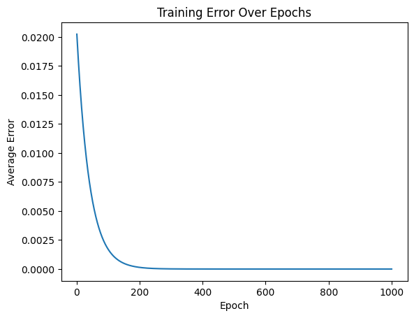

```
Output: 0.4971570953933695
Mean Absolute Error: 0.002842904606630503
Mean Squared Error: 8.082106602400935e-06
```

```python
import numpy as np
import matplotlib.pyplot as plt
import sklearn.metrics as metrics

class NeuralNetwork:
    def __init__(self, input_size, hidden_layer_size, learning_rate):
        self.input_size = input_size
        self.hidden_layer_size = hidden_layer_size
        self.learning_rate = learning_rate

        self.weights_input_to_hidden = np.random.uniform(-1, 1, (input_size, hidden_layer_size))
        self.weights_hidden_to_output = np.random.uniform(-1, 1, hidden_layer_size)

    def sigmoid(self, x):
        return 1 / (1 + np.exp(-x))

    def feed_forward(self, inputs):
        hidden_layer_output = self.sigmoid(np.dot(inputs, self.weights_input_to_hidden))
        output = self.sigmoid(np.dot(hidden_layer_output, self.weights_hidden_to_output))
        return output

    def train(self, inputs, target, epochs):
        errors = []
        for epoch in range(epochs):
            hidden_layer_output = self.sigmoid(np.dot(inputs, self.weights_input_to_hidden))
            output = self.sigmoid(np.dot(hidden_layer_output, self.weights_hidden_to_output))

            error = target - output

            self.weights_hidden_to_output += error * self.learning_rate * hidden_layer_output
            self.weights_input_to_hidden += np.outer(inputs, error * self.learning_rate * self.weights_hidden_to_output * hidden_layer_output * (1 - hidden_layer_output))

            errors.append(np.mean(np.abs(error)))
            print(f'Epoch {epoch + 1}, Average Error: {errors[-1]}')

        # Plot the training error over epochs
        plt.plot(range(1, epochs + 1), errors)
        plt.xlabel('Epoch')
        plt.ylabel('Average Error')
        plt.title('Training Error Over Epochs')
        plt.show()

# Example usage
np.random.seed(0)  # for reproducibility

neural_network = NeuralNetwork(4, 3, 0.1)

inputs = np.array([0.1, 0.2, 0.3, 0.4])
target = 0.5

neural_network.train(inputs, target, epochs=1000)

test_inputs = np.array([0.5, 0.6, 0.7, 0.8])
output = neural_network.feed_forward(test_inputs)

print("Output:", output)

print("Mean Absolute Error:", metrics.mean_absolute_error([target], [output]))
print("Mean Squared Error:", metrics.mean_squared_error([target], [output]))
```

## AO die nummers kan voorspellen.

```python
import numpy as np
from scipy.optimize import minimize
from scipy.io import loadmat
from sklearn.metrics import mean_absolute_error, mean_squared_error


def predict(Model, Dummies, X):
	m = X.shape[0]
	one_matrix = np.ones((m, 1))
	X = np.append(one_matrix, X, axis=1) # Adding bias unit to first layer
	z2 = np.dot(X, Model.transpose())
	a2 = 1 / (1 + np.exp(-z2)) # Activation for second layer
	one_matrix = np.ones((m, 1))
	a2 = np.append(one_matrix, a2, axis=1) # Adding bias unit to hidden layer
	z3 = np.dot(a2, Dummies.transpose())
	a3 = 1 / (1 + np.exp(-z3)) # Activation for third layer
	p = (np.argmax(a3, axis=1)) # Predicting the class on the basis of max value of hypothesis
	return p


def initialise(a, b):
    epsilon = 0.15
    c = np.random.rand(a, b + 1) * (
      # Randomly initialises values of data between [-epsilon, +epsilon]
      2 * epsilon) - epsilon
    return c


def neural_network(nn_params, input_layer_size, hidden_layer_size, num_labels, X, y, lamb):
    # Weights are split back to Model, Dummies
    Model = np.reshape(nn_params[:hidden_layer_size * (input_layer_size + 1)],
                        (hidden_layer_size, input_layer_size + 1))
    Dummies = np.reshape(nn_params[hidden_layer_size * (input_layer_size + 1):],
                        (num_labels, hidden_layer_size + 1))

    # Forward propagation
    m = X.shape[0]
    one_matrix = np.ones((m, 1))
    X = np.append(one_matrix, X, axis=1)  # Adding bias unit to first layer
    a1 = X
    z2 = np.dot(X, Model.transpose())
    a2 = 1 / (1 + np.exp(-z2))  # Activation for second layer
    one_matrix = np.ones((m, 1))
    a2 = np.append(one_matrix, a2, axis=1)  # Adding bias unit to hidden layer
    z3 = np.dot(a2, Dummies.transpose())
    a3 = 1 / (1 + np.exp(-z3))  # Activation for third layer

    # Changing the y labels into vectors of boolean values.
    # For each label between 0 and 9, there will be a vector of length 10
    # where the ith element will be 1 if the label equals i
    y_vect = np.zeros((m, 10))
    for i in range(m):
        y_vect[i, int(y[i])] = 1

    # Calculating cost function
    J = (1 / m) * (np.sum(np.sum(-y_vect * np.log(a3) - (1 - y_vect) * np.log(1 - a3)))) + (lamb / (2 * m)) * (
                sum(sum(pow(Model[:, 1:], 2))) + sum(sum(pow(Dummies[:, 1:], 2))))

    # backprop
    Delta3 = a3 - y_vect
    Delta2 = np.dot(Delta3, Dummies) * a2 * (1 - a2)
    Delta2 = Delta2[:, 1:]

    # gradient
    Model[:, 0] = 0
    Model_grad = (1 / m) * np.dot(Delta2.transpose(), a1) + (lamb / m) * Model
    Dummies[:, 0] = 0
    Dummies_grad = (1 / m) * np.dot(Delta3.transpose(), a2) + (lamb / m) * Dummies
    grad = np.concatenate((Model_grad.flatten(), Dummies_grad.flatten()))

    return J, grad


# Loading mat file
data = loadmat('mnist-original.mat')

# Extracting features from mat file
X = data['data']
X = X.transpose()

# Normalizing the data
X = X / 255

# Extracting labels from mat file
y = data['label']
y = y.flatten()

# Splitting data into training set with 60,000 examples
X_train = X[:60000, :]
y_train = y[:60000]

# Splitting data into testing set with 10,000 examples
X_test = X[60000:, :]
y_test = y[60000:]

m = X.shape[0]
input_layer_size = 784  # Images are of (28 X 28) px so there will be 784 features
hidden_layer_size = 100
num_labels = 10  # There are 10 classes [0, 9]

# Randomly initialising The Model itself and the Dummy variables
initial_Model = initialise(hidden_layer_size, input_layer_size)
initial_Dummies = initialise(num_labels, hidden_layer_size)

# Unrolling parameters into a single column vector
initial_nn_params = np.concatenate((initial_Model.flatten(), initial_Dummies.flatten()))
maxiter = 100
lambda_reg = 0.1  # To avoid overfitting
myargs = (input_layer_size, hidden_layer_size, num_labels, X_train, y_train, lambda_reg)

# Calling minimize function to minimize cost function and to train weights
results = minimize(neural_network, x0=initial_nn_params, args=myargs,
          options={'disp': True, 'maxiter': maxiter}, method="L-BFGS-B", jac=True)

nn_params = results["x"]  # Trained Data is extracted

# Weights are split back to Model, Dummies
Model = np.reshape(nn_params[:hidden_layer_size * (input_layer_size + 1)], (
                              hidden_layer_size, input_layer_size + 1))  # shape = (100, 785)
Dummies = np.reshape(nn_params[hidden_layer_size * (input_layer_size + 1):],
                      (num_labels, hidden_layer_size + 1))  # shape = (10, 101)

# Checking test set accuracy of our model
pred = predict(Model, Dummies, X_test)
print('Test Set Accuracy: {:f}'.format((np.mean(pred == y_test) * 100)))

# Checking train set accuracy of our model
pred = predict(Model, Dummies, X_train)
print('Training Set Accuracy: {:f}'.format((np.mean(pred == y_train) * 100)))

# Evaluating precision of our model
true_positive = 0
for i in range(len(pred)):
    if pred[i] == y_train[i]:
        true_positive += 1
false_positive = len(y_train) - true_positive
print('Precision =', true_positive/(true_positive + false_positive))

# Saving the data in .txt file
np.savetxt('Model.txt', Model, delimiter=' ')
np.savetxt('Dummies.txt', Dummies, delimiter=' ')
```

```
Test Set Accuracy: 97.470000
Training Set Accuracy: 99.441667
Precision = 0.9944166666666666
```

```python
from tkinter import *
import numpy as np
from PIL import ImageGrab

window = Tk()
window.title("Handwritten digit recognition")
l1 = Label()

def predict(Model, Dummies, X):
	m = X.shape[0]
	one_matrix = np.ones((m, 1))
	X = np.append(one_matrix, X, axis=1) # Adding bias unit to first layer
	z2 = np.dot(X, Model.transpose())
	a2 = 1 / (1 + np.exp(-z2)) # Activation for second layer
	one_matrix = np.ones((m, 1))
	a2 = np.append(one_matrix, a2, axis=1) # Adding bias unit to hidden layer
	z3 = np.dot(a2, Dummies.transpose())
	a3 = 1 / (1 + np.exp(-z3)) # Activation for third layer
	p = (np.argmax(a3, axis=1)) # Predicting the class on the basis of max value of hypothesis
	return p

def Prediction():
    global l1

    widget = cv
    # Setting co-ordinates of canvas
    x = window.winfo_rootx() + widget.winfo_x()
    y = window.winfo_rooty() + widget.winfo_y()
    x1 = x + widget.winfo_width()
    y1 = y + widget.winfo_height()

    # Image is captured from canvas and is resized to (28 X 28) px
    img = ImageGrab.grab().crop((x, y, x1, y1)).resize((28, 28))

    # Converting rgb to grayscale image
    img = img.convert('L')

    # Extracting pixel matrix of image and converting it to a vector of (1, 784)
    x = np.asarray(img)
    vec = np.zeros((1, 784))
    k = 0
    for i in range(28):
        for j in range(28):
            vec[0][k] = x[i][j]
            k += 1

    # Loading the Text.
    Model = np.loadtxt('Model.txt')
    Dummies = np.loadtxt('Dummies.txt')

    # Calling function for prediction
    pred = predict(Model, Dummies, vec / 255)

    # Displaying the result
    l1 = Label(window, text="Digit = " + str(pred[0]), font=('Calibri', 20))
    l1.place(x=260, y=420)


lastx, lasty = None, None


# Clears the canvas
def clear_widget():
    global cv, l1
    cv.delete("all")
    l1.destroy()


# Activate canvas
def event_activation(event):
    global lastx, lasty
    cv.bind('<B1-Motion>', draw_lines)
    lastx, lasty = event.x, event.y


# To draw on canvas
def draw_lines(event):
    global lastx, lasty
    x, y = event.x, event.y
    cv.create_line((lastx, lasty, x, y), width=20, fill='white', capstyle=ROUND, smooth=TRUE, splinesteps=12)
    lastx, lasty = x, y


# Label
L1 = Label(window, text="Handwritten Digit Recoginition", font=('Calibri', 25), fg="blue")
L1.place(x=100, y=10)

# Button to clear canvas
b1 = Button(window, text="1. Clear Canvas", font=('Calibri', 15), bg="orange", fg="black", command=clear_widget)
b1.place(x=120, y=370)

# Button to predict digit drawn on canvas
b2 = Button(window, text="2. Prediction", font=('Calibri', 15), bg="white", fg="red", command=Prediction)
b2.place(x=355, y=370)

# Setting properties of canvas
cv = Canvas(window, width=350, height=290, bg='black')
cv.place(x=120, y=70)

cv.bind('<Button-1>', event_activation)
window.geometry("600x500")
window.mainloop()
```